# Key Drivers of Transmission Type in Vehicles

Sean Schilk

10/5/2025

This project focuses on multiple logistic regression modeling. We will use the same data set as last week, mtcars

```r
# ?mtcars
data(mtcars)
head(mtcars)
```

```
                   mpg cyl disp  hp drat    wt  qsec vs am gear carb
Mazda RX4         21.0   6  160 110 3.90 2.620 16.46  0  1    4    4
Mazda RX4 Wag     21.0   6  160 110 3.90 2.875 17.02  0  1    4    4
Datsun 710        22.8   4  108  93 3.85 2.320 18.61  1  1    4    1
Hornet 4 Drive    21.4   6  258 110 3.08 3.215 19.44  1  0    3    1
Hornet Sportabout 18.7   8  360 175 3.15 3.440 17.02  0  0    3    2
Valiant           18.1   6  225 105 2.76 3.460 20.22  1  0    3    1
```

```r
# our binary response is am here, 0 = automatic, 1= manual transmission
```

This case study seeks to identify the factors associated with transmission type (manual vs automatic) in automobiles.

To begin, we generate pairwise scatter plots for all continuous numerical features to identify highly correlated predictors and to assess their distributional characteristics.

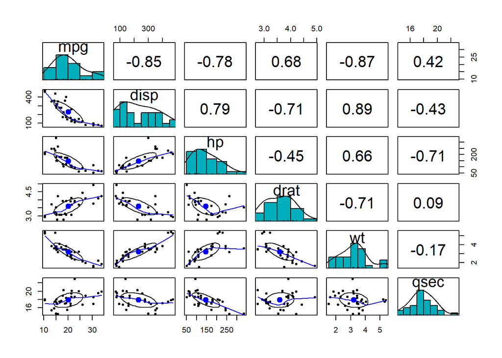

```r
library(psych)
pairs.panels(mtcars[, -c(2, 8, 10, 11, 9)],
             method = "pearson", # correlation method
             hist.col = "#00AFBB",
             density = TRUE,  # show density plots
             ellipses = TRUE # show correlation ellipses
             )
```

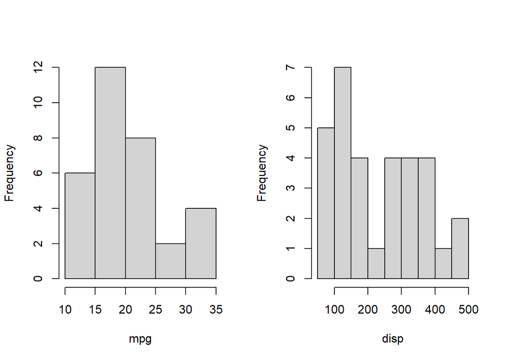

```r
par(mfrow=c(1,2))
hist(mtcars$mpg, xlab="mpg", main = "")
hist(mtcars$disp, xlab="disp", main = "")
```

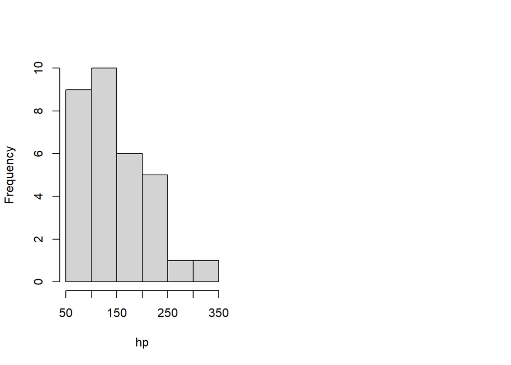

```r
hist(mtcars$hp, xlab="hp", main = "")
```

Based on the above histogram and the best clinical practices, we discretize disp and hp in the following.

```r
# disp is basically engine size
disc.disp = mtcars$disp
grp.disp = rep(NA, length(disc.disp))

grp.disp[disc.disp >= 50 & disc.disp <= 150] <- "Small"
grp.disp[disc.disp > 150 & disc.disp <= 300] <- "Medium"
grp.disp[disc.disp > 300] <- "Large"

mtcars$grp.disp <- grp.disp
##


## this method works because its all integers. If not, look at code above.
disc.hp = mtcars$hp
grp.hp = disc.hp
grp.hp[disc.hp %in% c(50:150)] = "Low"
grp.hp[disc.hp %in% c(151:250)] = "Medium"
grp.hp[disc.hp %in% c(251:400)] = "High"
## now add to dataset
mtcars$grp.disp = grp.disp
mtcars$grp.hp = grp.hp
```

Also, high correlations were observed in serveral pairs of variables: - mpg vs disp - mpg vs wt - disp vs wt - disp vs hp

will not drop any of these variables for the moment but will perform an automatic variable selection process to remove potential redundant variables since a few of them will be forced to be included in the final model.

Since our goal is association analysis, we will not perform variable transformations for the time being.

# 1 Building the MLR model

Based on the exploratory analysis above, the two engineered variables will be used in the following model building. We adopt the convention of defining a scope for the logistic model and then using automatic model selection to identify the optimal model within that scope.

```r
library(pander)
#notice we do not include the previous hp/disp variables, prior to discretizing
full.model = glm(am ~ grp.hp + grp.disp + mpg + cyl + drat + wt + qsec + vs + gear + carb,
                 family = binomial(link = "logit"),
                 data = mtcars)
pander(summary(full.model)$coef,
      caption="Summary of inferential statistics of the full model")
```

Summary of inferential statistics of the full model

|  | Estimate | Std. Error | z value | Pr(>\|z\|) |
| --- | --- | --- | --- | --- |
| **(Intercept)** | 74.9 | 12477190 | 6.003e-06 | 1 |
| **grp.hpLow** | -68.63 | 707269 | -9.703e-05 | 0.9999 |
| **grp.hpMedium** | -70.25 | 627290 | -0.000112 | 0.9999 |
| **grp.dispMedium** | 38.45 | 579865 | 6.63e-05 | 0.9999 |
| **grp.dispSmall** | 42.09 | 2118553 | 1.987e-05 | 1 |
| **mpg** | -1.385 | 62417 | -2.22e-05 | 1 |
| **cyl** | 5.87 | 570496 | 1.029e-05 | 1 |
| **drat** | 46.36 | 1085648 | 4.27e-05 | 1 |
| **wt** | -9.032 | 465140 | -1.942e-05 | 1 |
| **qsec** | -13.54 | 352419 | -3.842e-05 | 1 |
| **vs** | -30.58 | 545769 | -5.603e-05 | 1 |
| **gear** | 36.51 | 757808 | 4.818e-05 | 1 |
| **carb** | -24.09 | 277451 | -8.682e-05 | 0.9999 |

Our full model is struggling to converge. Let’s check the multicollinearity. The following table shows the VIF for each individual variable

```r
library(car)
vif(full.model)
```

```
               GVIF Df GVIF^(1/(2*Df))
grp.hp    725.46267  2        5.189838
grp.disp 2157.14582  2        6.815063
mpg       102.39422  1       10.119003
cyl       802.07256  1       28.320886
drat       81.93948  1        9.052043
wt         54.52705  1        7.384243
qsec      315.81421  1       17.771162
vs         54.73712  1        7.398454
gear      134.28759  1       11.588252
carb      167.66748  1       12.948648
```

We have large GVIF values for all variables. There is significant multicollinearity issues, so let’s remove some. We should not keep multiple variables that are measuring the same physical thing (engine size/power/weight) in different forms.

```r
refit.model = glm(am ~ hp + disp,
                 family = binomial(link = "logit"),
                 data = mtcars)
pander(summary(refit.model)$coef,
      caption="Summary of inferential statistics of the refit model")
```

Summary of inferential statistics of the refit model

|  | Estimate | Std. Error | z value | Pr(>\|z\|) |
| --- | --- | --- | --- | --- |
| **(Intercept)** | 1.403 | 1.368 | 1.026 | 0.3048 |
| **hp** | 0.1217 | 0.06777 | 1.796 | 0.07254 |
| **disp** | -0.09518 | 0.048 | -1.983 | 0.04739 |

```r
vif(refit.model)
```

```
      hp     disp
47.24825 47.24825
```

Our VIF values are above 10, so we have significant multicollinearity issues with this model.

# 2 Reduced Model

```r
reduced.model = glm(am ~ hp,
          family = binomial(link = "logit"),  # logit(p) = log(p/(1-p))!
          data = mtcars)
pander(summary(reduced.model)$coef,
      caption="Summary of inferential statistics of the reduced model")
```

Summary of inferential statistics of the reduced model

|  | Estimate | Std. Error | z value | Pr(>\|z\|) |
| --- | --- | --- | --- | --- |
| **(Intercept)** | 0.7766 | 0.9154 | 0.8484 | 0.3962 |
| **hp** | -0.008117 | 0.006074 | -1.336 | 0.1815 |

The reduced model may use insufficient information, resulting in underfitting (missing important effects), while the full model can lead to overfitting (modeling noise and failing to generalize). To address this, we use automatic variable selection to find a simpler, more interpretable, and better-performing model by intelligently choosing a subset of predictors that includes the important variables from the reduced model while avoiding the noise of the full model.

```r
## automatic variable selection
#library(MASS)
final.model.forward = stepAIC(reduced.model,
                      scope = list(lower=formula(reduced.model),upper=formula(refit.model)),
                      direction = "forward",   # forward selection
                      trace = 0   # do not show the details
                      )
pander(summary(final.model.forward)$coef,
      caption="Summary of inferential statistics of the final model")
```

Summary of inferential statistics of the final model

|  | Estimate | Std. Error | z value | Pr(>\|z\|) |
| --- | --- | --- | --- | --- |
| **(Intercept)** | 1.403 | 1.368 | 1.026 | 0.3048 |
| **hp** | 0.1217 | 0.06777 | 1.796 | 0.07254 |
| **disp** | -0.09518 | 0.048 | -1.983 | 0.04739 |

We next use deviance and AIC as measures to assess the performance of the above three models. The model with the lowest AIC value is generally preferred, as it indicates a superior balance between goodness-of-fit and model complexity, penalizing unnecessary parameters. Similarly, an analysis of deviance, which measures the discrepancy between the model and the observed data, allows us to perform likelihood-ratio tests to formally compare nested models. By examining these two criteria together, we can identify the most parsimonious model that best explains the underlying structure of the data without overfitting.

```r
## Other global goodness-of-fit
global.measure=function(s.logit){
dev.resid = s.logit$deviance
dev.0.resid = s.logit$null.deviance
aic = s.logit$aic
goodness = cbind(Deviance.residual =dev.resid, Null.Deviance.Residual = dev.0.resid,
      AIC = aic)
goodness
}
goodness=rbind(refit.model = global.measure(refit.model),
      reduced.model=global.measure(reduced.model),
      final.model=global.measure(final.model.forward))
row.names(goodness) = c("refit.model", "reduced.model", "final.model")
pander(goodness, caption ="Comparison of global goodness-of-fit statistics")
```

Comparison of global goodness-of-fit statistics

|  | Deviance.residual | Null.Deviance.Residual | AIC |
| --- | --- | --- | --- |
| **refit.model** | 16.71 | 43.23 | 22.71 |
| **reduced.model** | 41.23 | 43.23 | 45.23 |
| **final.model** | 16.71 | 43.23 | 22.71 |

Deviance.residual(reduced.model) - Deviance.residual(final.model) = 41.23 - 16.71 = 24.52

```r
pchisq(16.71, df = 1, lower.tail = FALSE)
```

```
[1] 4.355083e-05
```

This is a highly significant pvalue, indicating the 2 models are statistically different, and therefore we select the final model.

```r
library(knitr)
# Odds ratio
model.coef.stats = summary(final.model.forward)$coef
odds.ratio = exp(coef(final.model.forward))
out.stats = cbind(model.coef.stats, odds.ratio = odds.ratio)
kable(out.stats,caption = "Summary Stats with Odds Ratios")
```

Summary Stats with Odds Ratios

|  | Estimate | Std. Error | z value | Pr(>\|z\|) | odds.ratio |
| --- | --- | --- | --- | --- | --- |
| (Intercept) | 1.4034220 | 1.3675666 | 1.026218 | 0.3047886 | 4.0691008 |
| hp | 0.1217017 | 0.0677732 | 1.795721 | 0.0725390 | 1.1294172 |
| disp | -0.0951797 | 0.0480028 | -1.982794 | 0.0473904 | 0.9092095 |

The interpretation of the odds ratios is similar to the case of simple logistic regression. For a 1 unit increase in horsepower, the odds of a car’s transmission being manual increase by 13%, disp constant.

# 3 Remarks

Definitely too small of a data set to properly discretize and do MLR. However we did come to a nice, interpretable outcome. High correlation’s between variables are still problematic, even in our final model.